# RestoreDART raw result graphs by ecoregion

BEM

September 2026

## Notes

- This document is **reference material**, split out of `2_sample_size_checks.Rmd` because it is bulky: one bar-panel figure per surviving ecoregion per objective, which is the large majority of the figures the project renders. Nothing here is summarised or tested - it is the closest the report gets to showing the raw per-pixel results, with significant and non-significant pixels plotted together. For what the data can support see `2_sample_size_checks.Rmd`; for results across objectives see `2_make_DART_results.Rmd`.

### cover: AFG, objective: decrease_afg

- The primary spatial dimension of interest is `us_l4name`, while the primary temporal dimension of interest is `year_diff`. The only relevant explanatory variable at this point in the analysis is `tx_coarse`.
- Both significant and non-significant pixels should be plotted.
- Only post-treatment data should be plotted.

The year x treatment x ecoregion heatmap that used to open this subsection (`plot_all_DART_sig()`, “Where are treated areas significantly shifting?”) has been removed. It carried the net direction of significant pixels as a diverging fill over a year x treatment grid, faceted by ecoregion, with cells under 30 pixels faded; with five objectives and up to 28 ecoregions each it was one dense panel grid per objective and the bar panels below say the same thing on axes that can be read off directly. The function was moved to `archive/retired_functions.R` on 07 October 2026, when a reachability check over the live documents found nothing calling it; it takes `metric = 'prop_sig'` as well as the default net-direction fill, so the figure can be brought back by sourcing that file and restoring the one call at the top of the chunk below.

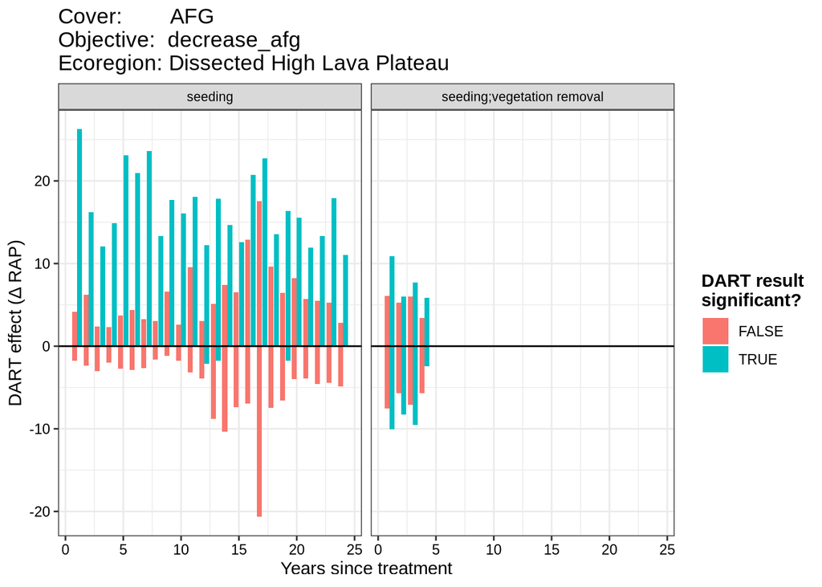

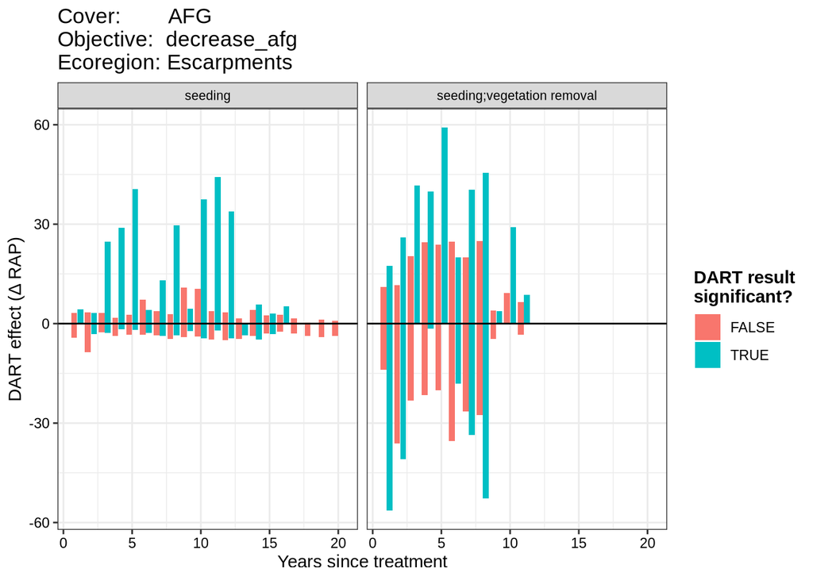

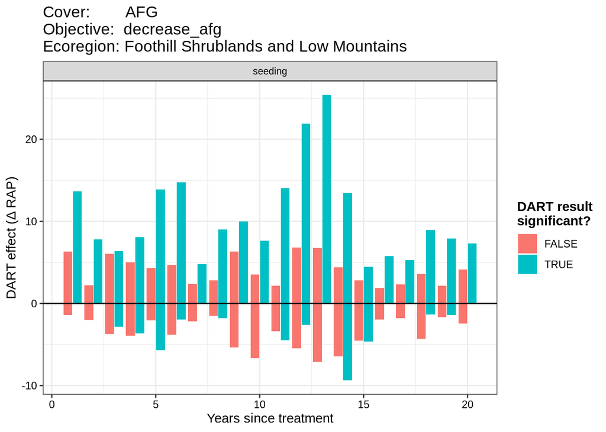

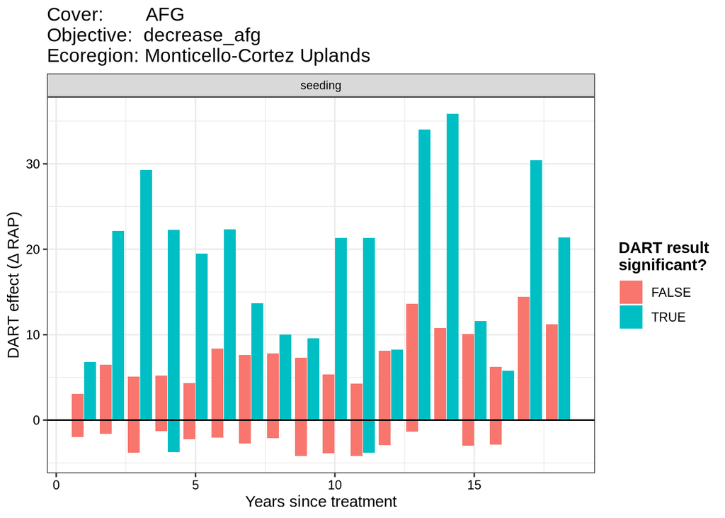

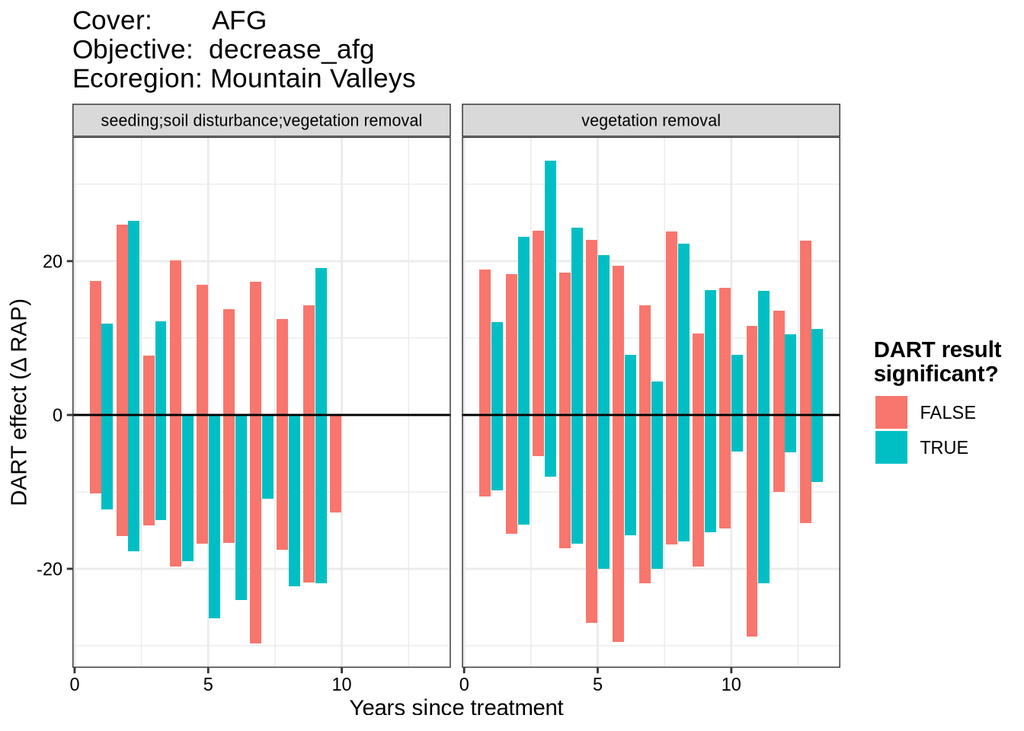

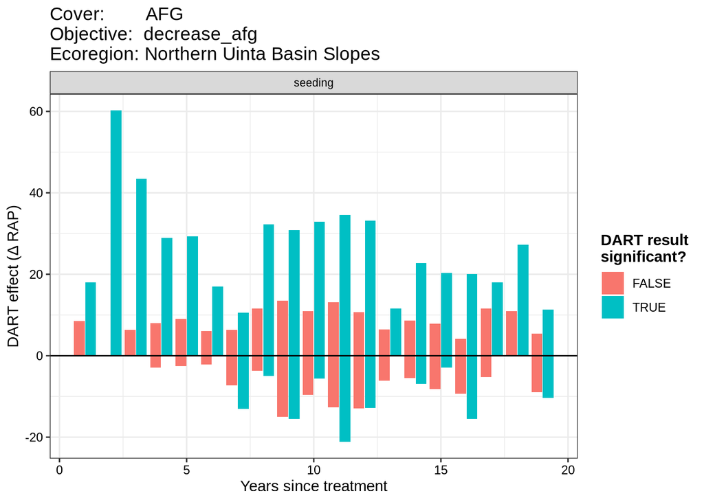

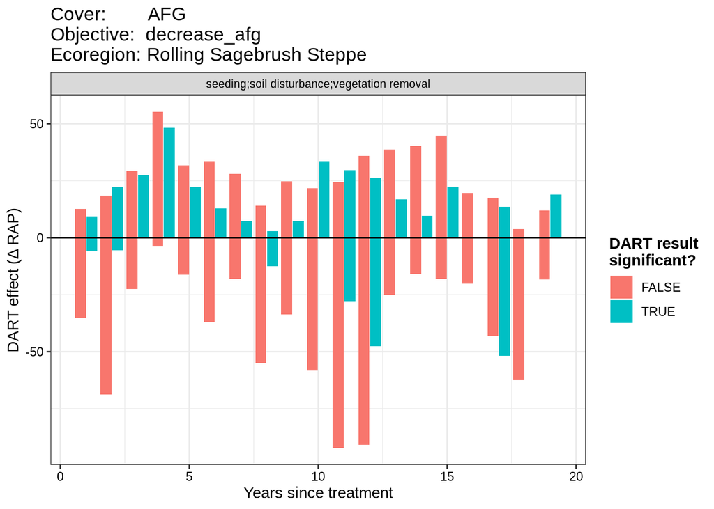

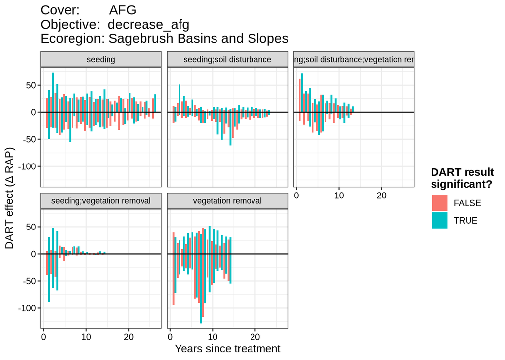

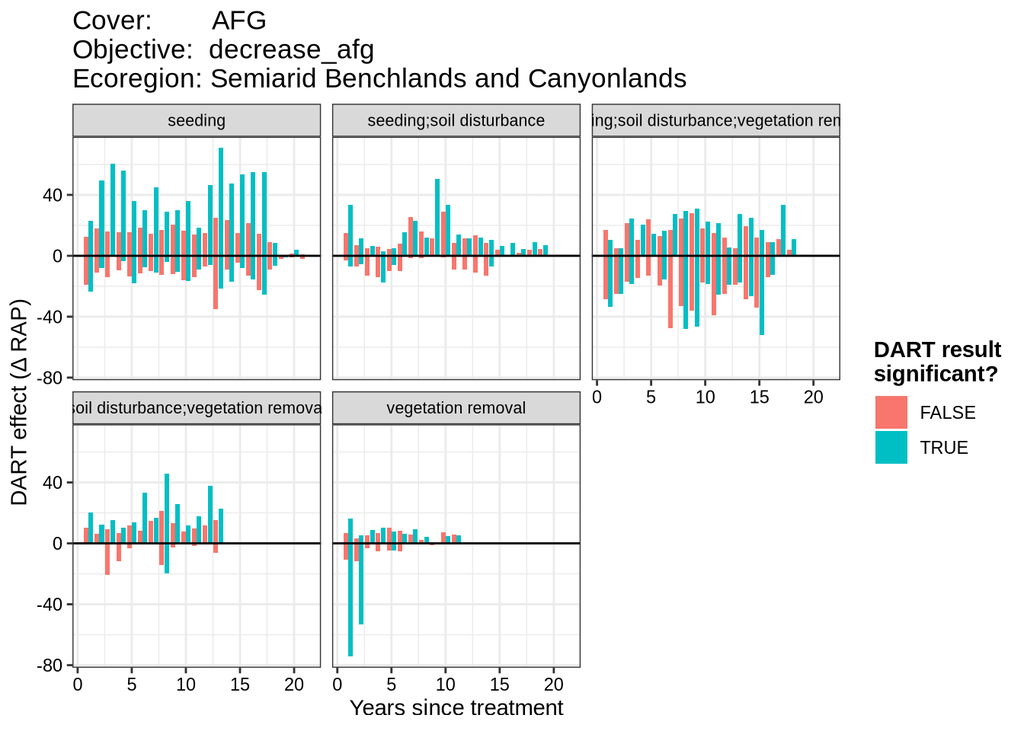

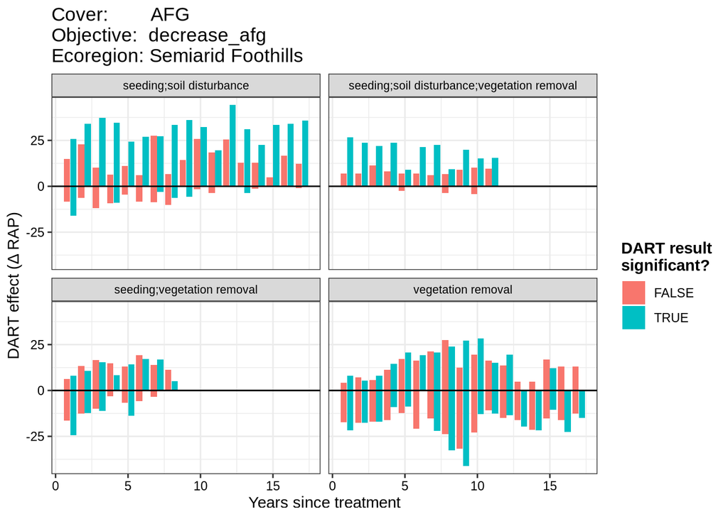

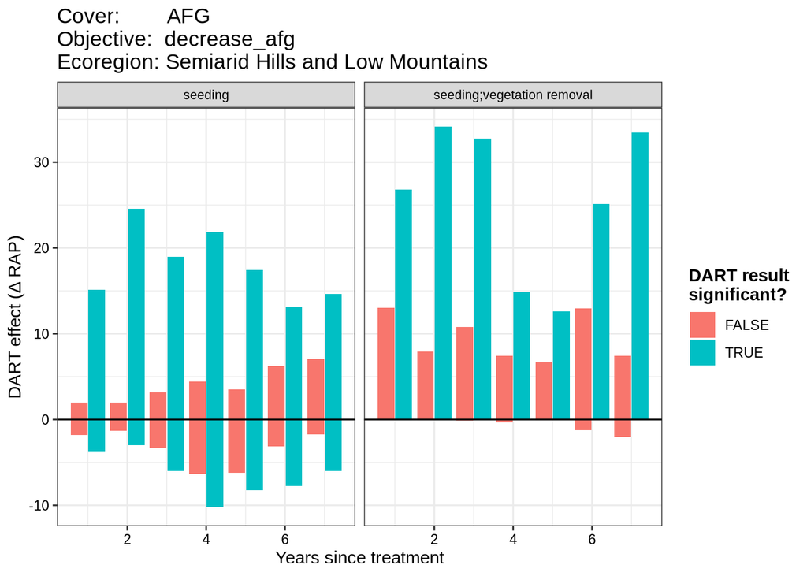

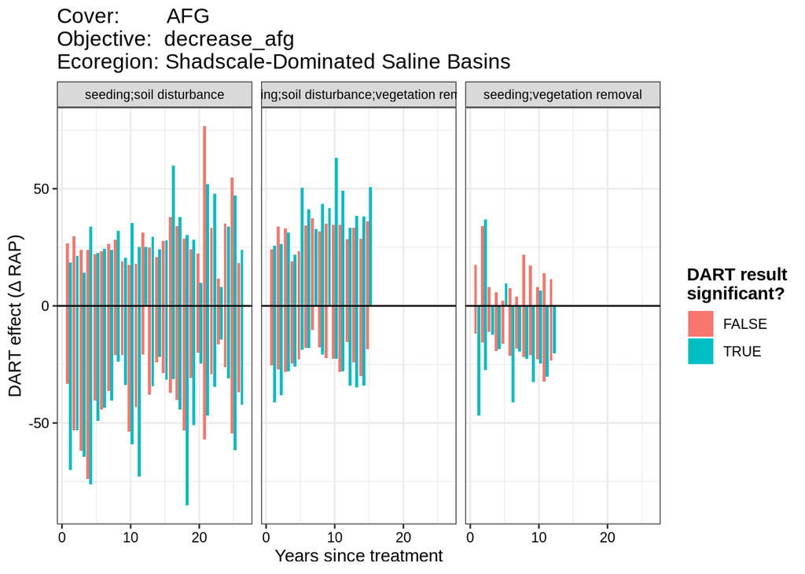

[2 more figures not shown]

**Figures (bar panels, one figure per ecoregion).** X axis: years since treatment. Y axis: DART effect (Δ RAP cover), with a line at zero. Fill: whether the DART result was significant (`TRUE`/`FALSE`), the two dodged side by side within each year. Facets: coarse treatment, one panel each. One figure is drawn per ecoregion, named in the figure title along with the cover response and objective.

For the decrease_afg objective, significant bars should generally fall on the negative side of the zero line. Significant bars on the positive side would indicate that the treatment is not producing the intended change. Non-significant bars neither support nor refute treatment efficacy.

### cover: SHR, objective: decrease_shr

- The primary spatial dimension of interest is `us_l4name`, while the primary temporal dimension of interest is `year_diff`. The only relevant explanatory variable at this point in the analysis is `tx_coarse`.
- Both significant and non-significant pixels should be plotted.
- Only post-treatment data should be plotted.

The year x treatment x ecoregion heatmap that used to open this subsection (`plot_all_DART_sig()`, “Where are treated areas significantly shifting?”) has been removed. It carried the net direction of significant pixels as a diverging fill over a year x treatment grid, faceted by ecoregion, with cells under 30 pixels faded; with five objectives and up to 28 ecoregions each it was one dense panel grid per objective and the bar panels below say the same thing on axes that can be read off directly. The function was moved to `archive/retired_functions.R` on 07 October 2026, when a reachability check over the live documents found nothing calling it; it takes `metric = 'prop_sig'` as well as the default net-direction fill, so the figure can be brought back by sourcing that file and restoring the one call at the top of the chunk below.

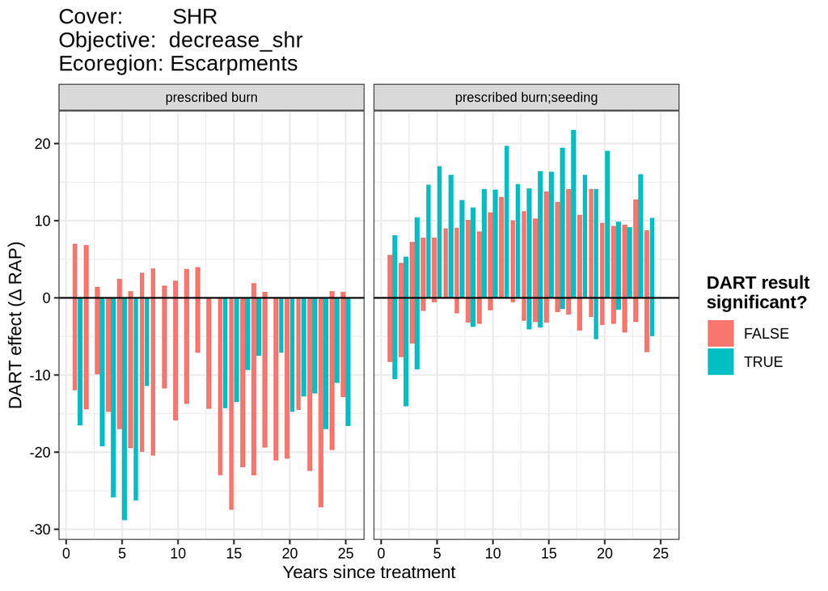

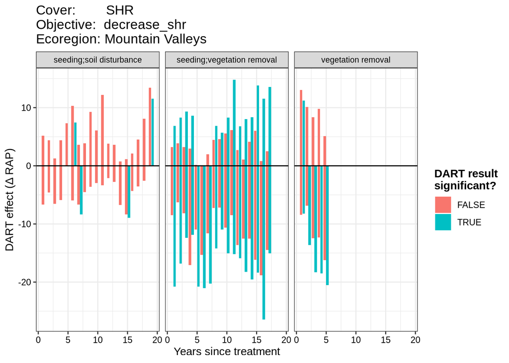

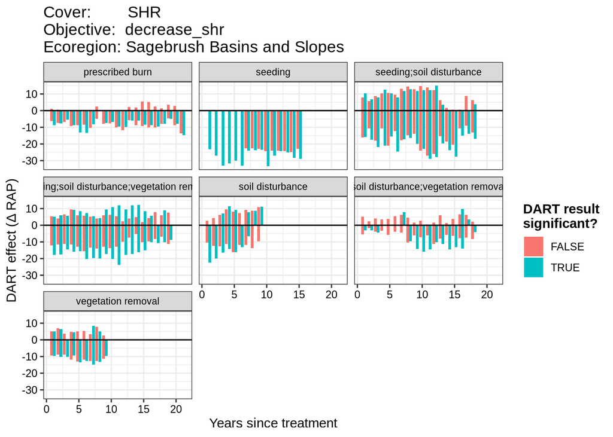

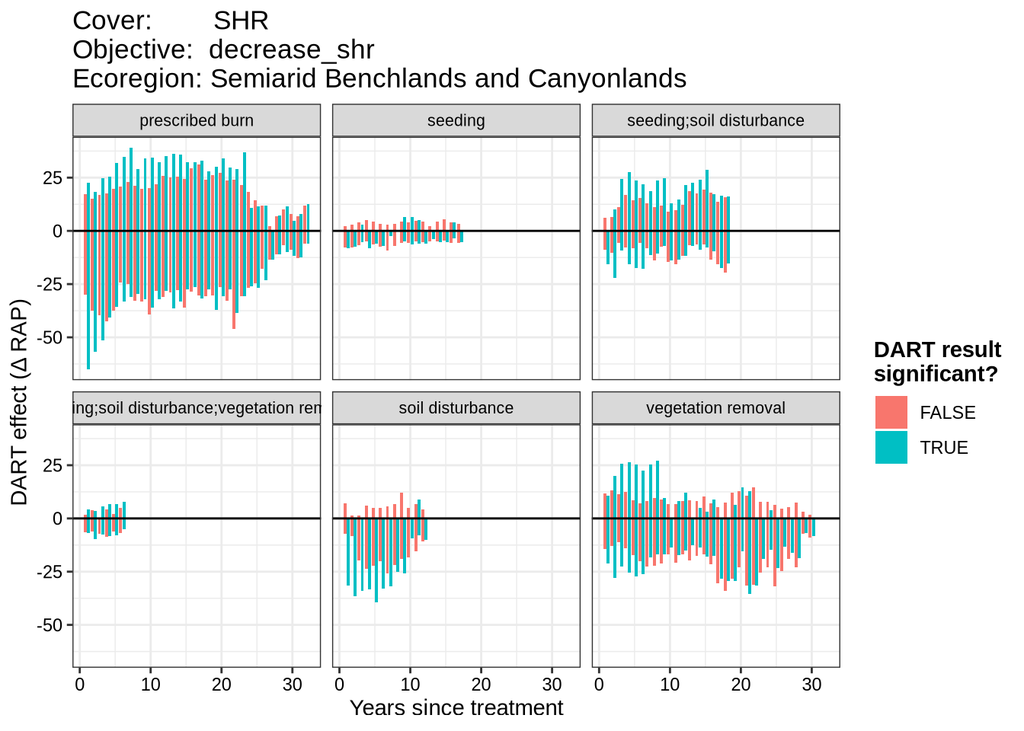

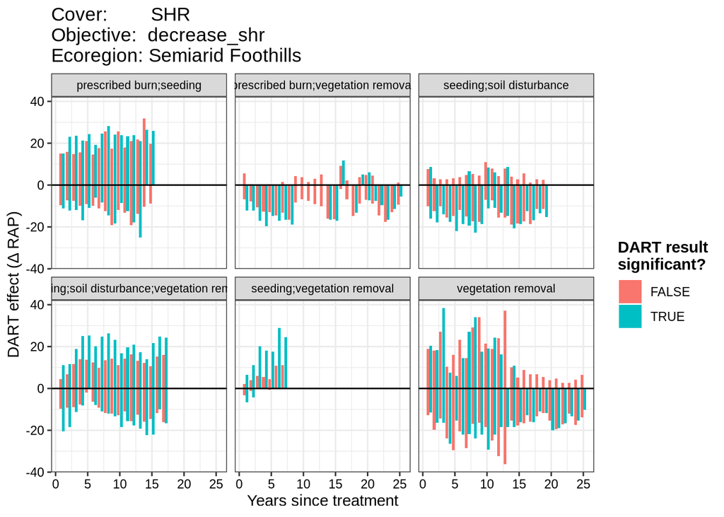

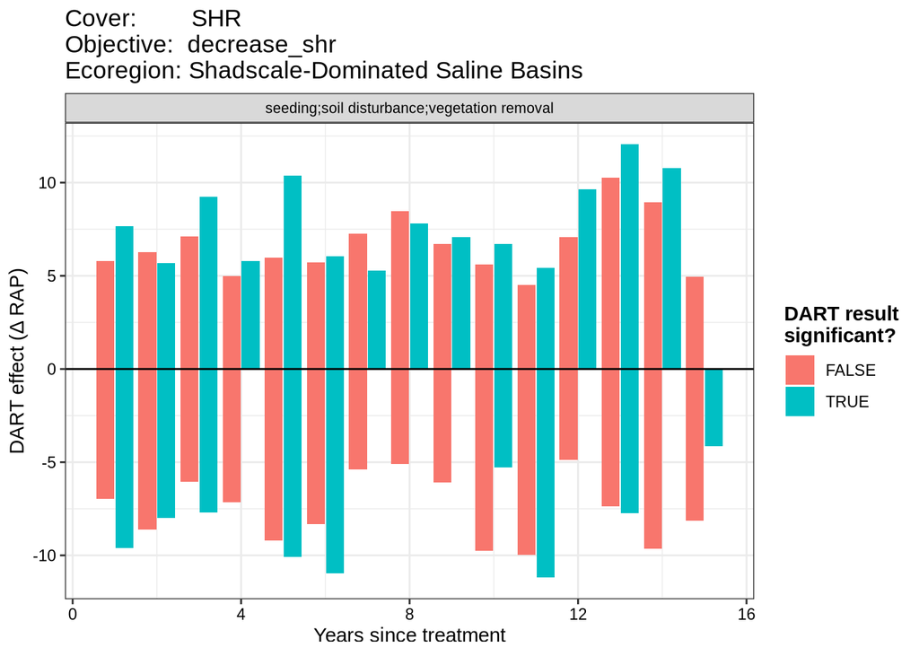

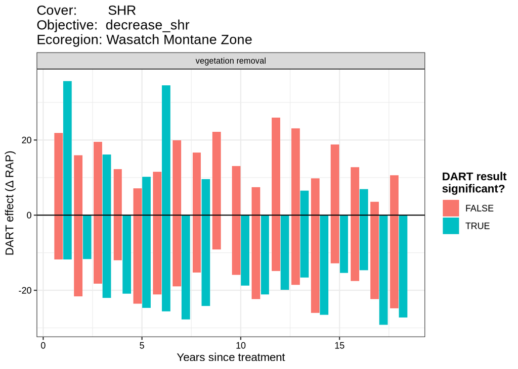

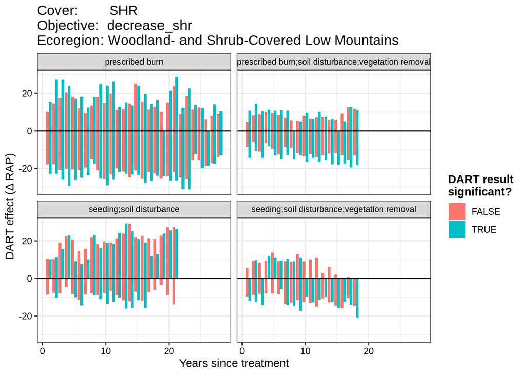

**Figures (bar panels, one figure per ecoregion).** X axis: years since treatment. Y axis: DART effect (Δ RAP cover), with a line at zero. Fill: whether the DART result was significant (`TRUE`/`FALSE`), the two dodged side by side within each year. Facets: coarse treatment, one panel each. One figure is drawn per ecoregion, named in the figure title along with the cover response and objective.

For the decrease_shr objective, significant bars should generally fall on the negative side of the zero line. Significant bars on the positive side would indicate that the treatment is not producing the intended change. Non-significant bars neither support nor refute treatment efficacy.

### cover: TRE, objective: decrease_tre

- The primary spatial dimension of interest is `us_l4name`, while the primary temporal dimension of interest is `year_diff`. The only relevant explanatory variable at this point in the analysis is `tx_coarse`.
- Both significant and non-significant pixels should be plotted.
- Only post-treatment data should be plotted.

The year x treatment x ecoregion heatmap that used to open this subsection (`plot_all_DART_sig()`, “Where are treated areas significantly shifting?”) has been removed. It carried the net direction of significant pixels as a diverging fill over a year x treatment grid, faceted by ecoregion, with cells under 30 pixels faded; with five objectives and up to 28 ecoregions each it was one dense panel grid per objective and the bar panels below say the same thing on axes that can be read off directly. The function was moved to `archive/retired_functions.R` on 07 October 2026, when a reachability check over the live documents found nothing calling it; it takes `metric = 'prop_sig'` as well as the default net-direction fill, so the figure can be brought back by sourcing that file and restoring the one call at the top of the chunk below.

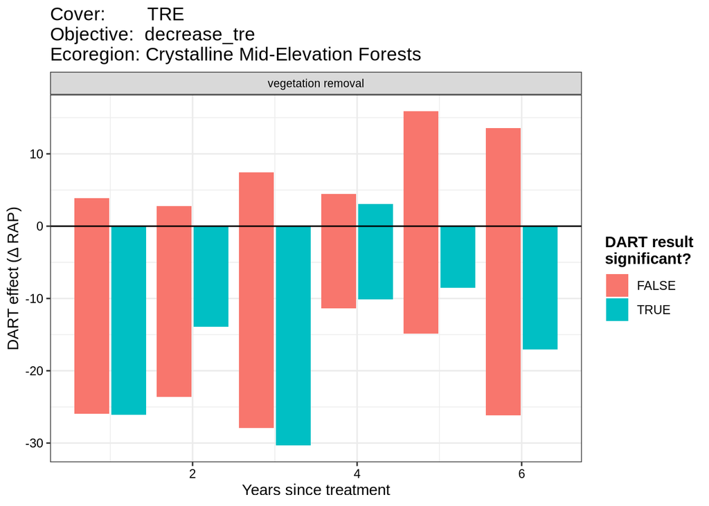

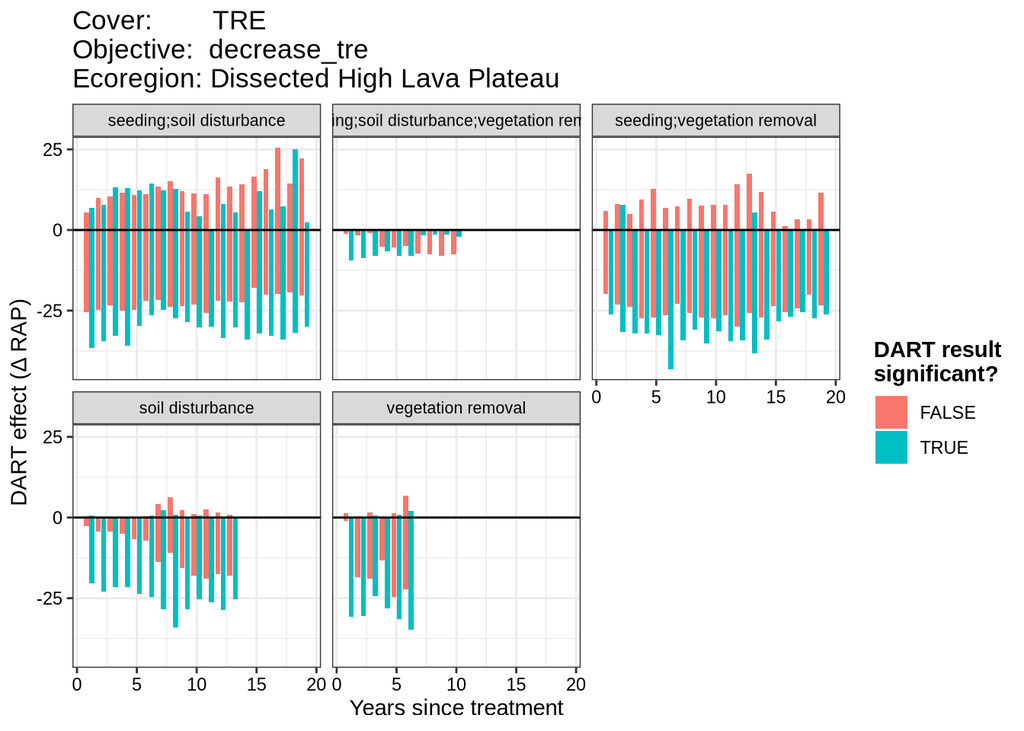

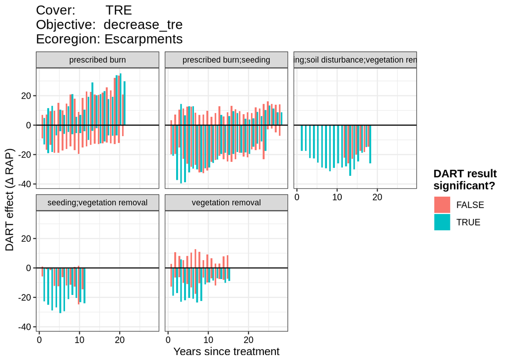

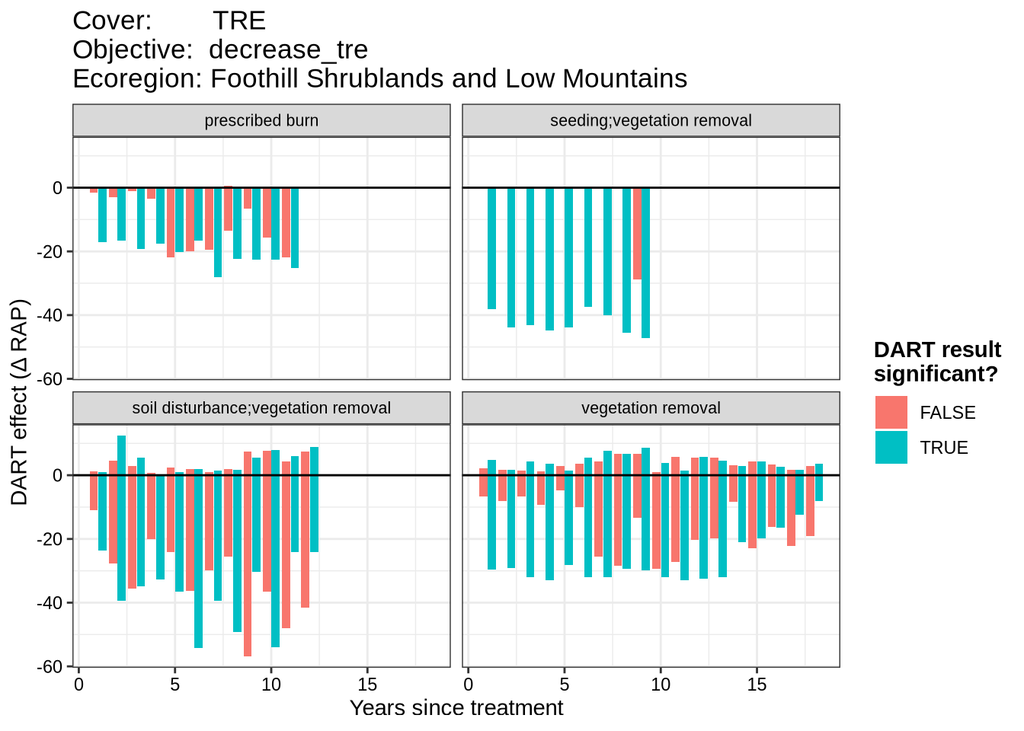

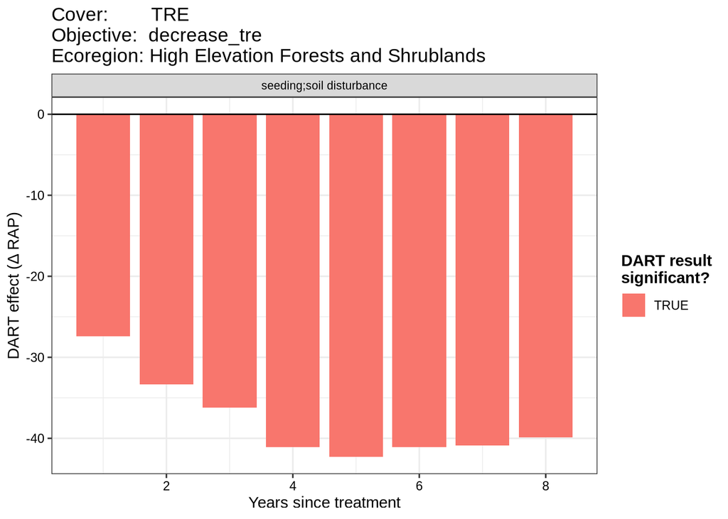

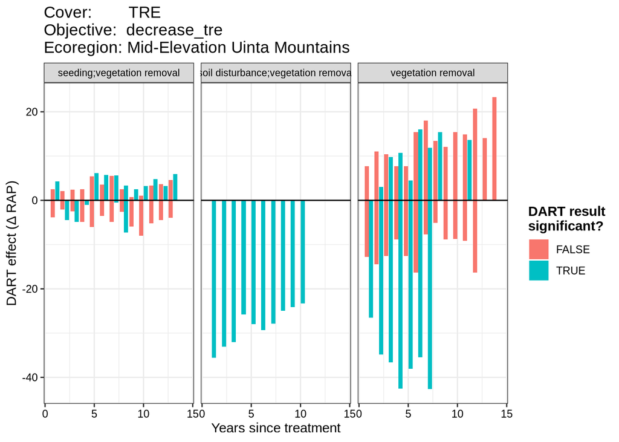

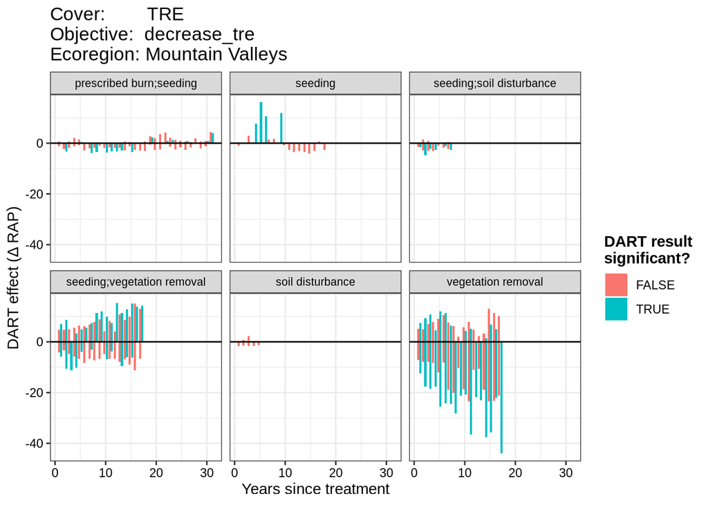

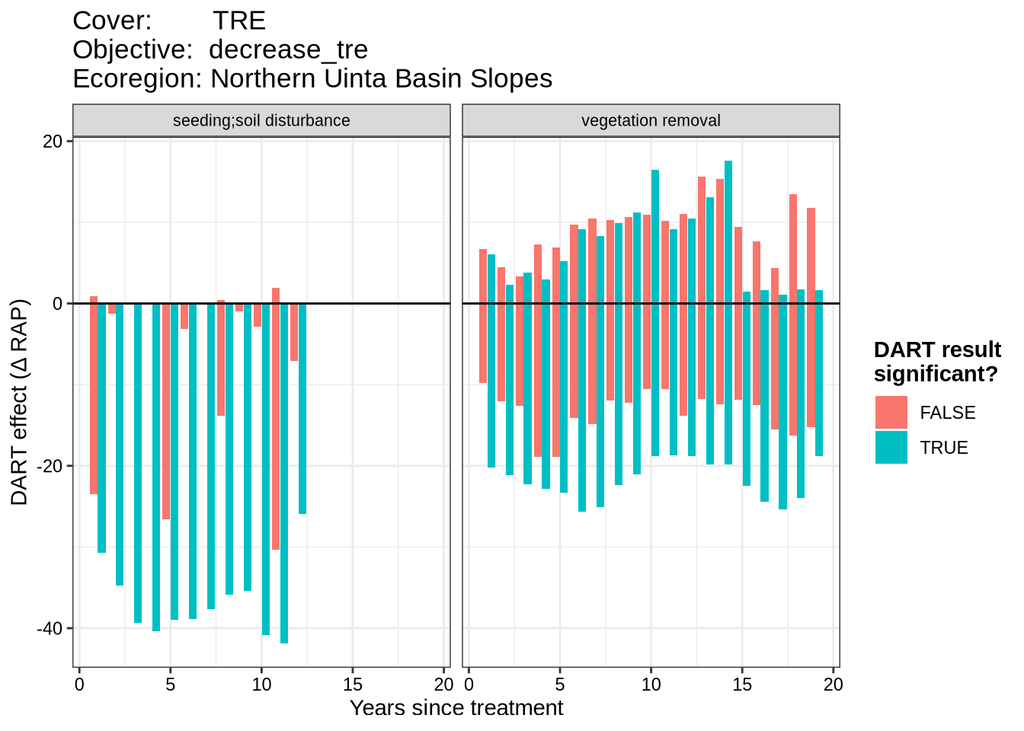

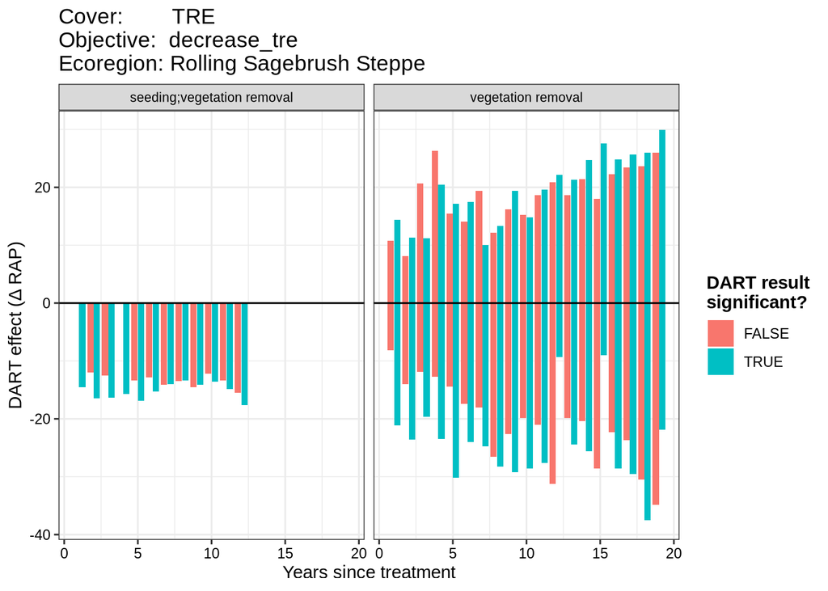

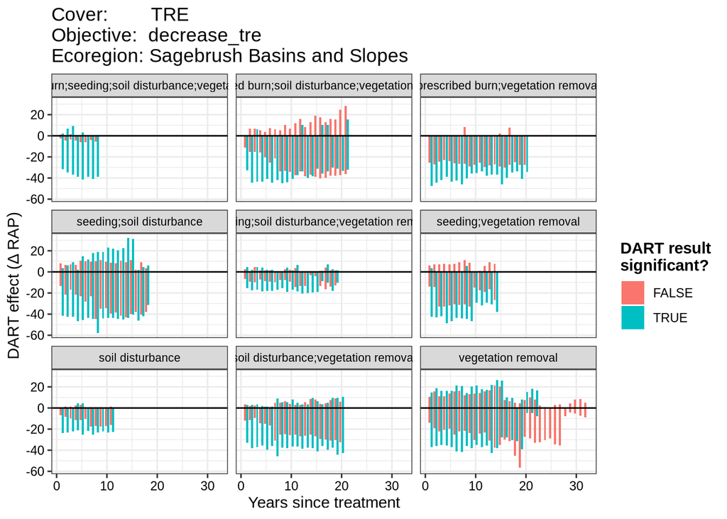

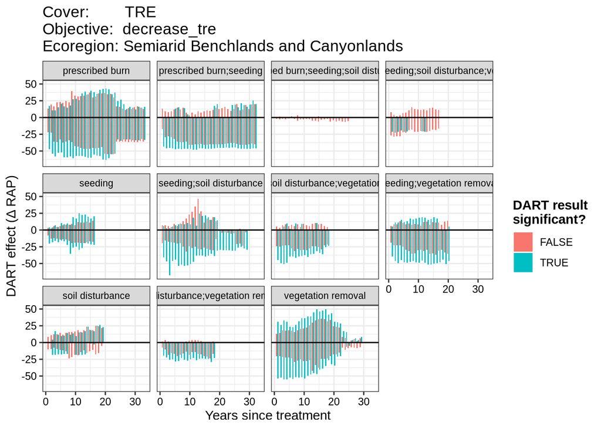

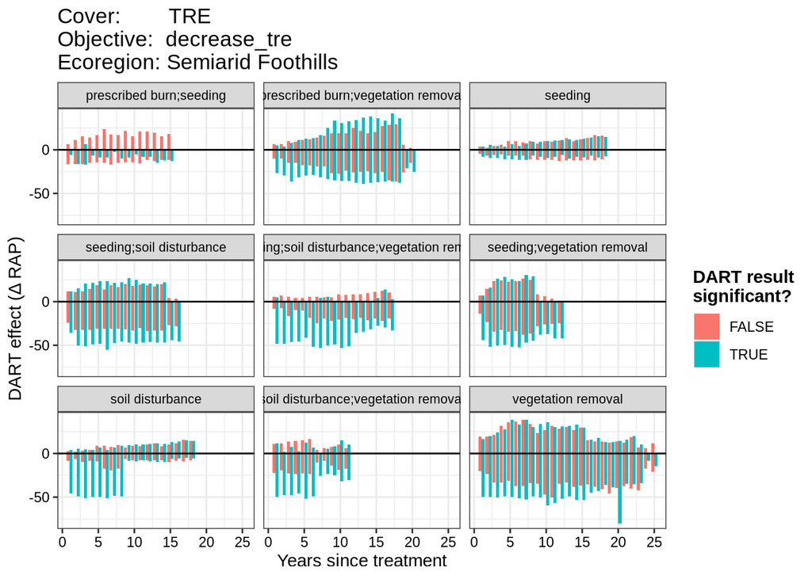

[3 more figures not shown]

**Figures (bar panels, one figure per ecoregion).** X axis: years since treatment. Y axis: DART effect (Δ RAP cover), with a line at zero. Fill: whether the DART result was significant (`TRUE`/`FALSE`), the two dodged side by side within each year. Facets: coarse treatment, one panel each. One figure is drawn per ecoregion, named in the figure title along with the cover response and objective.

For the decrease_tre objective, significant bars should generally fall on the negative side of the zero line. Significant bars on the positive side would indicate that the treatment is not producing the intended change. Non-significant bars neither support nor refute treatment efficacy.